# Getting Started

### Installation

To use Turing, you need to install Julia first and then install Turing.

You will need to install Julia 1.10.8 or greater, which you can get from [the official Julia website](http://julialang.org/downloads/).

Turing is officially registered in the [Julia General package registry](https://github.com/JuliaRegistries/General), which means that you can install a stable version of Turing by running the following in the Julia REPL:

```julia
using Pkg
Pkg.add("Turing")
```

### Supported versions and platforms

Formally, we only run continuous integration tests on: (1) the minimum supported minor version (typically an LTS release), and (2) the latest minor version of Julia. We test on Linux (x64), macOS (Apple Silicon), and Windows (x64). The Turing developer team will prioritise fixing issues on these platforms and versions.

If you run into a problem on a different version (e.g. older patch releases) or platforms (e.g. 32-bit), please do feel free to [post an issue](https://github.com/TuringLang/Turing.jl/issues/new?template=01-bug-report.yml)! If we are able to help, we will try to fix it, but we cannot guarantee support for untested versions.

### Example usage

First, we load the Turing and StatsPlots modules. The latter is required for visualising the results.

```julia
using Turing
using StatsPlots
```

We then specify our model, which is a simple Gaussian model with unknown mean and variance. Models are defined as ordinary Julia functions, prefixed with the `@model` macro. Each statement inside closely resembles how the model would be defined with mathematical notation. Here, both `x` and `y` are observed values, and are therefore passed as function parameters. `m` and `s²` are the parameters to be inferred.

```julia
@model function gdemo(x, y)
    s² ~ InverseGamma(2, 3)
    m ~ Normal(0, sqrt(s²))
    x ~ Normal(m, sqrt(s²))
    y ~ Normal(m, sqrt(s²))
end
```

```
gdemo (generic function with 2 methods)
```

Suppose we observe `x = 1.5` and `y = 2`, and want to infer the mean and variance. We can pass these data as arguments to the `gdemo` function, and run a sampler to collect the results. Here, we collect 1000 samples using the No U-Turn Sampler (NUTS) algorithm.

```julia
chain = sample(gdemo(1.5, 2), NUTS(), 1000, progress=false)
```

```
┌ Info: Found initial step size
└   ϵ = 1.6
```

```
Chains MCMC chain (1000×16×1 Array{Float64, 3}):

Iterations        = 501:1:1500
Number of chains  = 1
Samples per chain = 1000
Wall duration     = 3.97 seconds
Compute duration  = 3.97 seconds
parameters        = s², m
internals         = n_steps, is_accept, acceptance_rate, log_density, hamiltonian_energy, hamiltonian_energy_error, max_hamiltonian_energy_error, tree_depth, numerical_error, step_size, nom_step_size, logprior, loglikelihood, logjoint

Use `describe(chains)` for summary statistics and quantiles.
```

We can plot the results:

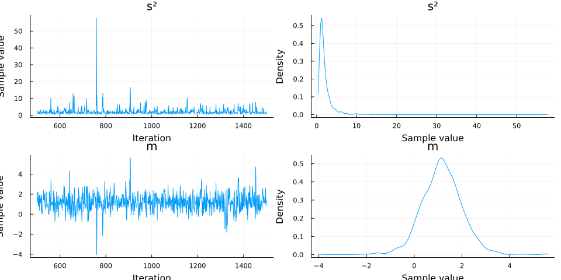

```julia
plot(chain)
```

and obtain summary statistics by indexing the chain:

```julia
mean(chain[:m]), mean(chain[:s²])
```

```
(1.1683040914571077, 2.063203038406717)
```

### Where to go next

**NoteNote on prerequisites**

Familiarity with Julia is assumed throughout the Turing documentation. If you are new to Julia, [Learning Julia](https://julialang.org/learning/) is a good starting point.

The underlying theory of Bayesian machine learning is not explained in detail in this documentation. A thorough introduction to the field is [*Pattern Recognition and Machine Learning*](https://www.springer.com/us/book/9780387310732) (Bishop, 2006); an online version is available [here (PDF, 18.1 MB)](https://www.microsoft.com/en-us/research/uploads/prod/2006/01/Bishop-Pattern-Recognition-and-Machine-Learning-2006.pdf).

The next page on Turing’s core functionality explains the basic features of the Turing language. From there, you can either look at worked examples of how different models are implemented in Turing, or specific tips and tricks that can help you get the most out of Turing.